# Vignette 2: Single trait analysis at correlated locations

This vignette builds on the information in [Vignette 1](https://jendelman.github.io/StageWise/Vignette1.html), which covered analysis at a single location. This vignette illustrates how to model the covariance between multiple locations, using a dataset of potato yield trials across 8 locations (TX was excluded) and 6 years, with a population of 336 genotypes ([Schmitz Carley et al. 2019](https://doi.org/10.2135/cropsci2018.05.0314)).

```r
library(StageWise)
geno.file <- system.file("vignette_data", "geno2.csv", package = "StageWise")
geno <- read_geno(filename=geno.file,ploidy=4,map=FALSE,dominance=TRUE)
```

```
## Minor allele threshold = 5 genotypes
## Number of markers = 5262
## Number of genotypes = 336
```

```r
pheno.file <- system.file("vignette_data", "pheno2.csv", package = "StageWise")
pheno <- read.csv(pheno.file)
head(pheno)
```

```
##           id loc     env Yield.Mg.ha
## 1  A01143-3C  CA CA_2011       90.98
## 2  A01143-3C  CA CA_2011       95.12
## 3 AC00206-2W  CA CA_2011       74.44
## 4 AC01151-5W  CA CA_2011       74.44
## 5 AC01151-5W  CA CA_2011       95.12
## 6 AC03452-2W  CA CA_2011       86.85
```

```r
table(pheno$loc)
```

```
##
##  CA  FL  MI  MO  NC  NY  OR  WI
## 804 815 820 482 847 832 612 757
```

The input file contains not only a column named ‘env’ for environment but also one named ‘loc’ for location. The location information is not explicitly used by `Stage1` but is automatically detected and retained in the output for use in `Stage2`.

```r
ans1 <- Stage1(filename=pheno.file, traits='Yield.Mg.ha')
```

```
## Offline License checked out Thu Jul 18 03:16:21 2024
```

```r
head(ans1$blues)
```

```
##       env          id    BLUE loc
## 1 CA_2011   A01143-3C  93.050  CA
## 2 CA_2011  AC00206-2W  74.440  CA
## 3 CA_2011  AC01151-5W  84.780  CA
## 4 CA_2011  AC03452-2W  86.850  CA
## 5 CA_2011  AC05153-1W  49.630  CA
## 6 CA_2011 Accumulator 105.455  CA
```

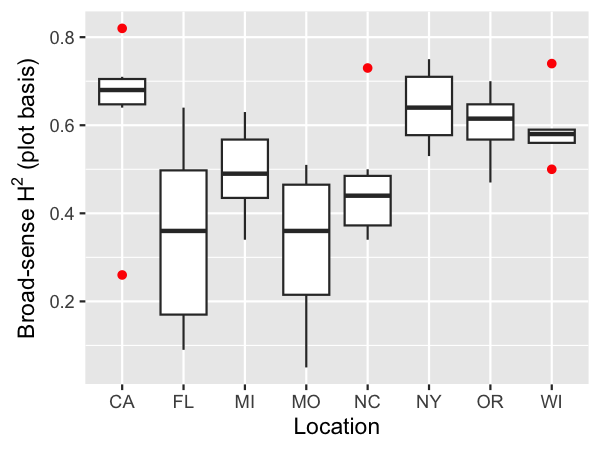

```r
library(ggplot2)
ggplot(data=ans1$fit,aes(x=loc,y=H2)) + stat_boxplot(outlier.color="red") + xlab("Location") + ylab(expression(paste("Broad-sense ",H^2," (plot basis)")))
```

The above figure shows the variation in broad-sense heritability across locations and years.

When the data frame of BLUEs passed to `Stage2` has a column labeled ‘loc’, genotype x location effects are included using a separable covariance structure. The genetic covariance between locations for the highest order genetic effect (i.e., additive when marker data are included) follows a 2nd order factor-analytic (FA2) model. (For non-additive genetic effects, the correlation is constrained at 1.) For large datasets with many locations (such as this one), I recommend first analyzing it without marker data, as the computation proceeds more quickly.

Here is a joint analysis of the 8 locations without using the marker data.

```r
ans2a <- Stage2(data=ans1$blues, vcov=ans1$vcov)
```

```r
summary(ans2a$vars)
```

```
## $var
##              Variance   PVE
## env               286    NA
## genotype           53 0.355
## g x loc            15 0.098
## g x env            22 0.150
## Stage1.error       59 0.397
##
## $cor
##       CA    FL    MI    MO    NC    NY    OR    WI
## CA 1.000 0.642 0.685 0.728 0.839 0.686 0.869 0.751
## FL 0.642 1.000 0.665 0.711 0.699 0.699 0.734 0.717
## MI 0.685 0.665 1.000 0.932 0.860 0.930 0.908 0.932
## MO 0.728 0.711 0.932 1.000 0.921 0.998 0.972 0.999
## NC 0.839 0.699 0.860 0.921 1.000 0.904 0.953 0.928
## NY 0.686 0.699 0.930 0.998 0.904 1.000 0.956 0.996
## OR 0.869 0.734 0.908 0.972 0.953 0.956 1.000 0.979
## WI 0.751 0.717 0.932 0.999 0.928 0.996 0.979 1.000
```

As in the single location analysis, running the `summary` command on the ‘vars’ output shows the partitioning of variance, but now a g x loc effect is also present. Because g x year effects are not repeatable and often small, they are not included in the `Stage2` model.

The FA2 model should have enough complexity for a set of correlated locations used by a single breeding program, but it may be inadequate when analyzing disparate locations. The factor loadings returned by `Stage2` can be used with the function `uniplot` to visualize model sufficiency and correlation structure ([Cullis et al. 2010](https://doi.org/10.1139/G10-080)).

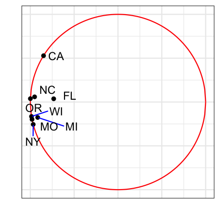

```r
uniplot(ans2a$loadings)
```

The squared radius for each location is the proportion of variance explained (PVE) by the latent factors. With the exception of FL, the FA2 model appears to provide a good representation of the covariance structure. The numeric PVE values can be obtained as follows:

```r
apply(ans2a$loadings,1,norm,type="f")^2
```

```
##        CA        FL        MI        MO        NC        NY        OR        WI
## 1.0000000 0.5388560 0.8694623 1.0000000 0.9077776 1.0000000 1.0000000 1.0000000
```

The cosine of the angle between locations equals the correlation due to the latent factors (recall cos(0) = 1). Focusing on the 6 highly correlated locations-WI,MI,NC,OR,NY,MO-we now add the marker data to `Stage2` to estimate the additive correlation and predict breeding values.

```r
locs <- c("WI","MI","OR","NY","NC","MO")
blues <- ans1$blues[ans1$blues$loc %in% locs,]
tmp <- sapply(strsplit(names(ans1$vcov),split="_"),"[[",1)
vcov <- ans1$vcov[tmp %in% locs]
```

```r
ans2b <- Stage2(data=blues,vcov=vcov,geno=geno,non.add="g.resid")
ans2c <- Stage2(data=blues,vcov=vcov,geno=geno,non.add="dom")
```

```r
data.frame(non.add=c("g.resid","dom"), AIC=c(ans2b$aic,ans2c$aic))
```

```
##   non.add      AIC
## 1 g.resid 16725.00
## 2     dom 16694.96
```

The dominance model is selected over the genetic residual model because of its lower AIC.

```r
summary(ans2c$vars)
```

```
## $var
##              Variance   PVE
## env               311    NA
## additive           35 0.208
## add x loc           8 0.046
## dominance          36 0.211
## heterosis           4 0.024
## g x env            20 0.117
## Stage1.error       67 0.393
##
## $cor
##       MI    MO    NC    NY    OR    WI
## MI 1.000 0.881 0.700 0.884 0.890 0.908
## MO 0.881 1.000 0.907 0.934 0.976 0.939
## NC 0.700 0.907 1.000 0.737 0.831 0.707
## NY 0.884 0.934 0.737 1.000 0.945 0.967
## OR 0.890 0.976 0.831 0.945 1.000 0.961
## WI 0.908 0.939 0.707 0.967 0.961 1.000
```

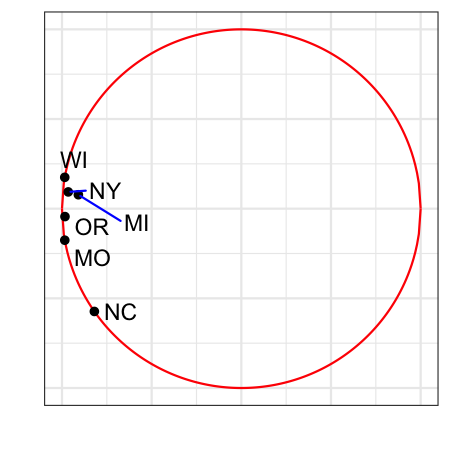

```r
uniplot(ans2c$loadings)
```

The correlation matrix and uniplot, which are based on the additive values, show that yield in NC was somewhat different compared to the other five sites.

Compared to the single location analysis in Vignette 1, an additional argument is needed for the `blup` function to specify the index coefficients, which are interpreted as the relative weight for each location after standardization to unit variance. The following code compares the reliability for BV predictions in WI vs. NC.

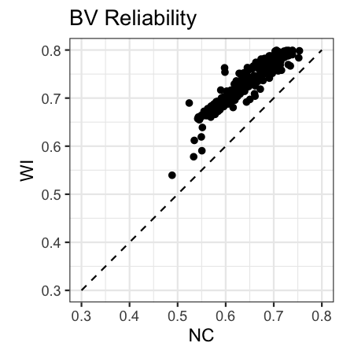

```r
prep1 <- blup_prep(data=blues,vcov=vcov,geno=geno,vars=ans2c$vars)

WI.index <- c(WI=1, NC=0, OR=0, NY=0, MO=0, MI=0)
NC.index <- c(WI=0, NC=1, OR=0, NY=0, MO=0, MI=0)

WI.pred <- blup(data=prep1,geno=geno,index.coeff=WI.index,what="BV")
NC.pred <- blup(data=prep1,geno=geno,index.coeff=NC.index,what="BV")

pred <- merge(NC.pred,WI.pred,by="id")
colnames(pred) <- c("id","BV.NC","r2.NC","BV.WI","r2.WI")

ggplot(pred,aes(x=r2.NC,y=r2.WI)) + geom_point() + coord_fixed(ratio=1) + xlim(0.3,0.8) + ylim(0.3,0.8) + geom_line(data=data.frame(x=c(0.3,0.8),y=c(0.3,0.8)),mapping=aes(x=x,y=y),linetype=2) + theme_bw() +
  xlab("NC") + ylab("WI") + ggtitle("BV Reliability")
```

The above figure shows that breeding values were predicted with higher reliability in WI than NC, which is to be expected from the high correlation between WI and the other four sites (OR,MO,MI,NY) compared to NC.

The `mask` argument for `blup_prep` can be used to mask individuals at one or more locations, to explore the accuracy of prediction into new environments. Whereas the previous analysis determined the reliability of GEBVs in WI when WI phenotypes are available, the next analysis excludes WI phenotypes:

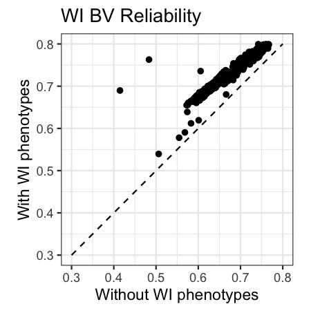

```r
WI.env <- unique(blues$env[blues$loc=="WI"])

prep2 <- blup_prep(data=blues,vcov=vcov,geno=geno,vars=ans2c$vars,
                   mask=data.frame(env=WI.env))

pred2 <- blup(data=prep2,geno=geno,index.coeff=WI.index,what="BV")

plot.data <- merge(pred2[,c("id","r2")],WI.pred[,c("id","r2")],by="id")
colnames(plot.data) <- c("id","without.WI.pheno","with.WI.pheno")

ggplot(plot.data,aes(x=without.WI.pheno,y=with.WI.pheno)) + geom_point() + coord_fixed(ratio=1) + xlim(0.3,0.8) + ylim(0.3,0.8) + geom_line(data=data.frame(x=c(0.3,0.8),y=c(0.3,0.8)),mapping=aes(x=x,y=y),linetype=2) + theme_bw() +
  xlab("Without WI phenotypes") + ylab("With WI phenotypes") + ggtitle("WI BV Reliability")
```

As expected, the reliability was higher with WI phenotypes.